# STIF image classifier

```python
import cv2 as cv2
```

```python
%%capture

! pip install -U "ray[default]"

! pip install bing-image-downloader
```

```python
import ray
```

```python
context = ray.init()

print(context.dashboard_url)
```

```
2023-06-11 12:18:14,277	INFO worker.py:1627 -- Started a local Ray instance. View the dashboard at 127.0.0.1:8265
```

```
127.0.0.1:8265
```

In this blog post we'll implement an image classification algorithm based on classic machine learning methods. The whole process is based on the STIF detectAndCompute algorithm, we use the image key points to compare images and make predictions. Let's see a basic example.

```python
from skimage import data, io, filters

import matplotlib.pyplot as plt

import numpy as np
```

```python
# basic STIF example:
```

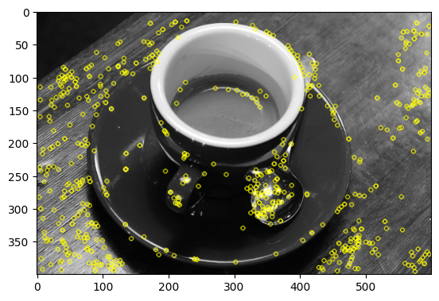

```python
img1 = data.coffee()

gray = cv2.cvtColor(img1, cv2.COLOR_BGR2GRAY)

sift = cv2.SIFT_create()

puntos = sift.detect(gray,None)

img2=cv2.drawKeypoints(gray,puntos,outImage=None,color=(255,255,0))

plt.imshow(img2)
```

First, we need an image dataset that we can use for the experiment, let's begin by writing a web-image-downloader and create the folder structure needed to classify and later predict. For this example we use the Bing image downloader to download multiple images from the web based on simple string queries.

```python
querys = ["cofee", "plane"]
```

The following function takes the input directory, reads all images inside it, and creates and output directory with the images splitted in train and test based on an indicated percentaje.

```python
import os

def split_copy(dir, out, test_split_at = 80):

  files = os.listdir(dir)

  path_train = os.path.join(out, 'train')
  path_test = os.path.join(out, 'test')

  if not os.path.exists(path_train):
    os.mkdir(path_train)

  if not os.path.exists(path_test):
    os.mkdir(path_test)

  for index in range(len(files)):

      filename = files[index]

      threshold = (int)(test_split_at * len(files) / 100)

      sub_dir =  path_train if (index < threshold) else path_test

      if filename.lower().endswith('.jpg'):

          import shutil

          src = os.path.join(dir, filename)
          dst = os.path.join(sub_dir, filename)

          shutil.copyfile(src, dst)
```

```python
from bing_image_downloader import downloader

def create_repo(querys, num = 20):

  for idx, q in enumerate(querys):

    downloader.download(
        q,
        limit=num,
        output_dir='dataset_t',
        adult_filter_off=True,
        force_replace=False,
        timeout=60,
        verbose=False)

    dataset_t = os.path.join('./dataset_t', q)
    dataset_r = os.path.join('./dataset_r', q)

    if not os.path.exists(dataset_r):
      os.makedirs(dataset_r)

    split_copy(dataset_t, dataset_r)

  # remove temp folder:
  import shutil

  try:
    shutil.rmtree('./dataset_t')
  except OSError as e:
      print("Error: %s - %s." % (e.filename, e.strerror))
```

```python
%%capture

create_repo(querys, 10)
```

```python
def STIF_desc_img(img_path):

    img2 = cv2.imread(img_path)

    gray = cv2.cvtColor(img2, cv2.COLOR_BGR2GRAY)

    sift = cv2.SIFT_create()

    _, t = sift.detectAndCompute(gray,None)

    return t
```

The following method is design to return a collection of arrays that can match the asociated image. Notice that each image contains a matrix with descriptors, we need a list of arrays to asociate the image.

```python
%%capture

! pip install tqdm

from tqdm import tqdm
```

```python
def feats_directory(dir, feats_all):

  for filename in tqdm(os.listdir(dir)):

      t_desc = STIF_desc_img(os.path.join(dir, filename))

      feats_all.append(t_desc)
```

```python
def get_subdir_list (rootdir, sub_fold_name):

  dirs_sub = []

  for file in os.listdir(rootdir):

    dir = os.path.join(rootdir, file)

    if os.path.isdir(dir):

      path_sub = os.path.join(dir, sub_fold_name)

      dirs_sub.append(path_sub)

  return dirs_sub
```

```python
dirs_train = get_subdir_list("./dataset_r", "train"); dirs_train

dirs_test = get_subdir_list("./dataset_r", "test"); dirs_test
```

```
['./dataset_r/cofee/test', './dataset_r/plane/test']
```

```python
%%time

feats_all = []

for dir in dirs_train:

  feats_directory(dir, feats_all)
```

```
CPU times: user 17.8 s, sys: 5.23 s, total: 23.1 s
Wall time: 30 s
```

```python
def get_target(dirs):

  y = []

  for idx_class, dir in enumerate(dirs):

    for index in range(len(os.listdir(dir))):

      y.append(idx_class)

  return y
```

```python
y_train = get_target(dirs_train)
y_test = get_target(dirs_test)
```

```python
feat_stack = np.vstack(feats_all)
```

```python
feat_stack.shape
```

```
(65107, 128)
```

```python
from sklearn.cluster import MiniBatchKMeans,KMeans

kmeans = MiniBatchKMeans(

    n_clusters=25,
    n_init="auto")

kmeans = kmeans.fit(feat_stack)
```

```python
# visualize cluster centers:

kmeans.cluster_centers_
```

```
array([[14.4897995, 21.393045 , 24.698425 , ..., 12.789873 , 10.885117 ,
        13.018521 ],
       [60.03194  , 20.94659  ,  6.481902 , ...,  6.8431377,  5.4162893,
         7.5311747],
       [13.086786 , 10.1923   , 11.730155 , ..., 16.217365 , 14.677135 ,
        17.317343 ],
       ...,
       [11.254995 ,  9.523686 , 14.480013 , ...,  5.6824546, 10.37158  ,
        11.07143  ],
       [27.440165 , 51.269386 , 43.336205 , ...,  8.680245 ,  5.1672006,
         8.536621 ],
       [19.475609 ,  8.099141 ,  6.2771745, ..., 19.135801 ,  2.9960146,
         4.4309835]], dtype=float32)
```

For any image that has some descriptors, we need to compute his word histogram based on the k-means labels that we have obtained. The k-means predict method returns the asociated cluster or label to each of the images STIF descriptor. The data has to be normalized before the return so we can build up the required matrix later.

```python
def get_word_hist(kmeans, STIF_desc):

  row = np.full(len(np.unique(kmeans.labels_)), 0)

  for idx, stif in enumerate(STIF_desc):

    desc = np.array(stif).reshape(1,128)

    label = kmeans.predict(desc)

    row[label] = row[label] +1

  # normalize

  return row / np.linalg.norm(row)
```

```python
# the following parallel exeution represent the building of the histogram matrix needed.
# Check how easily we can run remote operations and concatenate the results.

remote_word_hist = ray.remote(get_word_hist)

mat_2 = ray.get( [remote_word_hist.remote(kmeans, x) for x in feats_all])
```

Now, lets run different machine learning algorithms as a subprocess for the classificator that we are building, then compare the accuracy score obtained for each of them. The class structure allows to embed the concrete algorithm, for example different kmeans can be used to execute the process and then analize performance. The second parameter for the class constructor is the classification algorithm, check the following examples to understand how the STIFF_classifier and how the predict method is used with a concrete directory.

```python
from sklearn import svm

clasificador = svm.SVC(probability=True)

clasificador.fit(mat_2, y_train)
```

```
SVC(probability=True)
```

```python
img_path = os.path.join(dirs_test[0], os.listdir(dirs_test[0])[0])

t_desc = STIF_desc_img(img_path)

w_hist = get_word_hist(kmeans, t_desc)

clasificador.predict([get_word_hist(kmeans, t_desc)])
```

```
array([1])
```

Now, we create some wrapper classes to easily use the algorithms implemented, by using them in a correct way we can implement an elegant pipeline with different classificators and evaluate their precission. Notice that the STIFF_classificator takes to arguments for construction, it needs to use a kmeans implementation as well as classic algorithm for classification, once the histogram matrix is built.

```python
class STIF_img_classifier():

  # construct with algorithms:
  def __init__(self, kmeans, cls_alg):

    self.kmeans = kmeans

    self.cls_alg = cls_alg

  # to get the labels form repo:
  def labels(self, path_dir):

    return get_target(path_dir)

  def fit(self, path_dir, y_labels):

    # dinamycally decorate histogram_func;
    remote_word_hist = ray.remote(get_word_hist)

    # save labels:

    self.y_labels = y_labels

    self.feats_all = []

    for dir in path_dir:

      feats_directory(dir, self.feats_all)

    self.feat_stack = np.vstack(self.feats_all)

    self.kmeans.fit(self.feat_stack)

    self.mat_word_hist = ray.get([remote_word_hist.remote(self.kmeans, x) for x in self.feats_all])

    # # pass labels:
    self.cls_alg.fit(self.mat_word_hist, self.y_labels)

    return self.cls_alg

  def run_cls (self, cls_alg):

    # reasign the classifier:

    self.cls_alg = cls_alg

    self.cls_alg.fit(self.mat_word_hist, self.y_labels)

    return self.cls_alg

  def predict(self, img_path):

    t_desc = STIF_desc_img(img_path)

    w_hist = get_word_hist(kmeans, t_desc)

    return self.cls_alg.predict([w_hist])
```

```python
class IMG_rep_download():

  # construct with algorithm:

  def __init__(self, querys, n):

    self.querys = querys

    self.n = n

  def download(self):

    from bing_image_downloader import downloader

    # create the repo with n images for each class query;
    create_repo(self.querys, self.n)

  def get_train_dirs(self):

    return get_subdir_list("./dataset_r", "train")

  def get_test_dirs(self):

    return get_subdir_list("./dataset_r", "test")
```

Now, let see a basic example of how to use the previous classes. First we use the downloader to create the repository structure with the desired images. Each of the queries is going to generate train and test subfolders.

```python
import shutil

shutil.rmtree('./dataset_r')
```

```python
%%capture

r_dwn = IMG_rep_download(["alhambra gardens", "nyc skyline", "tokyo street neon" ], 15)

r_dwn.download()
```

```python
repo_train = r_dwn.get_train_dirs()
repo_test = r_dwn.get_test_dirs()
```

```python
from sklearn.cluster import MiniBatchKMeans, KMeans

kmeans = MiniBatchKMeans(

    n_clusters=25,
    n_init="auto")

svc = svm.SVC(probability=True)

stif_cls = STIF_img_classifier(kmeans, svc)

labels = stif_cls.labels(repo_train)

trained = stif_cls.fit(repo_train, labels)
```

```python
img_path = os.path.join(repo_test[0], os.listdir(repo_test[0])[0])

p_class = stif_cls.predict(img_path); p_class[0]
```

```
0
```

Once the STIFF classifier has been trained with the trained dataset, we need to test the performance againts the rest of the data. Since the dataset is already splitted into train/test/, we just need to predict for each of those test images to be able to construct the y_pred arrays that contains the class prediction for the test images.

```python
@ray.remote

def remote_predict(cls, img):

  return cls.predict(img)[0]

# get y_pred array for test images:

def get_y_pred(cls, test_dir):

  img_path = []

  # img_paths; and run parallel:

  for d in test_dir:

    for f in os.listdir(d):

      img_path.append(os.path.join(d, f))

  # img

  y_pred = ray.get( [remote_predict.remote(cls, img) for img in img_path] )

  return zip(img_path, y_pred)
```

```python
# asign y_true and y_pred;

y_true = get_target(repo_test)

zipped_preds = get_y_pred(stif_cls, repo_test)

img_paths, y_pred = list(zip(*zipped_preds))
```

```
(raylet) Spilled 2622 MiB, 3 objects, write throughput 78 MiB/s. Set RAY_verbose_spill_logs=0 to disable this message.
(raylet) Spilled 5244 MiB, 6 objects, write throughput 134 MiB/s.
```

[figure not shown]

```python
rows = 3
cols = 3
size = rows*cols
_, axs = plt.subplots(rows, cols, figsize=(12, 12))

axs = axs.flatten()

last = size if (len(img_paths) > size) else len(img_paths)

for idx in range(last):

  img = img_paths[idx]

  gray = cv2.imread(img, cv2.IMREAD_GRAYSCALE)

  sift = cv2.SIFT_create()

  puntos = sift.detect(gray,None)

  img2=cv2.drawKeypoints(gray,puntos,outImage=None,color=(255,255,0))

  axs[idx].imshow(img2)

  axs[idx].set_title("class:" + str(y_pred[idx]))

plt.show()
```

```python
from sklearn.metrics import accuracy_score

accuracy_score(y_true, y_pred)
```

```
0.8888888888888888
```

Now, let's run different machine learning algorithms as a subprocess for the classificator that we are building, then compare the accuracy score obtained for each of them. The class structure allows to embed the concrete algorithm, for example different classifiers can be used to execute the process and then analyze performance.

```python
# use same k-means:

from sklearn.cluster import MiniBatchKMeans, KMeans

kmeans = MiniBatchKMeans(

    n_clusters=25,
    n_init="auto")
```

```python
# trainning the base:

stif_cls = STIF_img_classifier(kmeans, svm.SVC(probability=True))

labels = stif_cls.labels(repo_train)

trained = stif_cls.fit(repo_train, labels)
```

```python
%%capture

# rest of algorithms:

from sklearn.neighbors import NearestCentroid

algs = [
    svm.SVC(probability=True),
    NearestCentroid(),
  ]

acc_res = {}

for al in algs:

  # run new classification algorithm over the trainned data:

  stif_cls.run_cls(al)

  zipped_preds = get_y_pred(stif_cls, repo_test)

  img_paths, y_pred = list(zip(*zipped_preds))

  score = accuracy_score(y_true, y_pred)

  acc_res[al.__class__.__name__ ] = score
```

```python
acc_res
```

```
{'SVC': 1.0, 'NearestCentroid': 0.6666666666666666}
```

[figure not shown]